# Firdaus Che Kob | Income Distribution 2

Income Distribution in Malaysia 2

[figure not shown]

##### Income Distribution in Malaysia Different Demographics

This is another Exploratory Data Analysis (EDA) on income distribution in Malaysia to look further into comparison by different demographics. I used matplotlib and seaborn to visualise the mean income by different education level, gender, ethnicity and industry.

From this analysis, we can see a strong correlation between highest education level attained by an individual and income earned. Men generally earn higher than women across different education level. We can also see the mean wage earned by different ethnicity and industry.

This dataset was imported from OpenDOSM, an open-sourced website by Department of Statistics Malaysia. It is based on The Salaries & Wages Survey, which collects data via a stratified two-stage sample design, thus obtaining representative data at the national and state level. The implementation of this survey is based on guidelines and recommendations of the International Labour Organization (ILO) with reference to An Integrated System of Wages Statistics.

```python
import pandas as pd
import numpy as np
import seaborn as sns
import matplotlib.pyplot as plt
%matplotlib inline

import warnings
warnings.filterwarnings("ignore")
```

```python
# Import all dataset
cert_df = pd.read_csv("salaries_certification_sex.csv")
ethnics_df = pd.read_csv("salaries_ethnicity_sex.csv")
industry_df = pd.read_csv("salaries_industry_sex.csv")
```

```python
cert_df.head()
```

|  | variable | variable_en | variable_bm | sex | year | mean | median | recipients |
| --- | --- | --- | --- | --- | --- | --- | --- | --- |
| 0 | overall | Overall | Keseluruhan | overall | 2010 | 1936.0 | 1500.0 | 7149200 |
| 1 | overall | Overall | Keseluruhan | overall | 2011 | 1959.0 | 1500.0 | 7634000 |
| 2 | overall | Overall | Keseluruhan | overall | 2012 | 2052.0 | 1566.0 | 7782900 |
| 3 | overall | Overall | Keseluruhan | overall | 2013 | 2186.0 | 1700.0 | 7903100 |
| 4 | overall | Overall | Keseluruhan | overall | 2014 | 2377.0 | 1800.0 | 8392400 |

```python
cert_df.describe()
```

|  | year | mean | median | recipients |
| --- | --- | --- | --- | --- |
| count | 216.000000 | 216.000000 | 216.000000 | 2.160000e+02 |
| mean | 2015.500000 | 2691.349074 | 2286.402778 | 1.877225e+06 |
| std | 3.460071 | 1303.158846 | 1171.029914 | 2.268984e+06 |
| min | 2010.000000 | 684.000000 | 600.000000 | 4.030000e+04 |
| 25% | 2012.750000 | 1783.750000 | 1500.000000 | 3.534500e+05 |
| 50% | 2015.500000 | 2408.600000 | 2000.000000 | 7.110000e+05 |
| 75% | 2018.250000 | 3226.750000 | 2806.500000 | 3.245450e+06 |
| max | 2021.000000 | 6838.000000 | 6250.000000 | 9.711900e+06 |

```python
cert_df.isnull().sum()
```

```
variable       0
variable_en    0
variable_bm    0
sex            0
year           0
mean           0
median         0
recipients     0
dtype: int64
```

```python
cert_df.info()
```

```
<class 'pandas.core.frame.DataFrame'>
RangeIndex: 216 entries, 0 to 215
Data columns (total 8 columns):
 #   Column       Non-Null Count  Dtype
---  ------       --------------  -----
 0   variable     216 non-null    object
 1   variable_en  216 non-null    object
 2   variable_bm  216 non-null    object
 3   sex          216 non-null    object
 4   year         216 non-null    int64
 5   mean         216 non-null    float64
 6   median       216 non-null    float64
 7   recipients   216 non-null    int64
dtypes: float64(2), int64(2), object(4)
memory usage: 13.6+ KB
```

```python
print('Education', cert_df.variable_en.unique())
```

```
Education ['Overall' 'No certificate/Not applicable' 'SPM and below'
 'STPM/Certificate ' 'Diploma' 'Degree']
```

```python
print('Year', cert_df.year.unique())
```

```
Year [2010 2011 2012 2013 2014 2015 2016 2017 2018 2019 2020 2021]
```

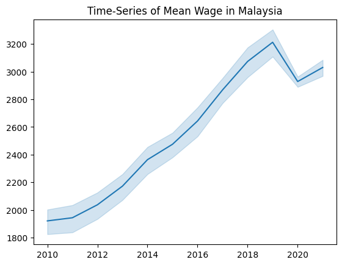

```python
# create a separate df for Overall value
overalldf = cert_df[cert_df['variable_en'].str.contains("Overall") == True]

# Plot the relationship between year and mean wage
g1 = sns.lineplot(data=overalldf, x="year", y="mean")
g1.set(xlabel="", ylabel="")

plt.title("Time-Series of Mean Wage in Malaysia")
plt.show()
```

```python
cert2_df = cert_df[cert_df['variable_en'] != 'Overall']
cert2_df[['variable_en', 'mean']].groupby(['variable_en'], as_index=False).mean().sort_values(by='mean', ascending=False)
```

|  | variable_en | mean |
| --- | --- | --- |
| 0 | Degree | 5015.658333 |
| 1 | Diploma | 3146.016667 |
| 4 | STPM/Certificate | 2380.583333 |
| 3 | SPM and below | 1822.477778 |
| 2 | No certificate/Not applicable | 1227.616667 |

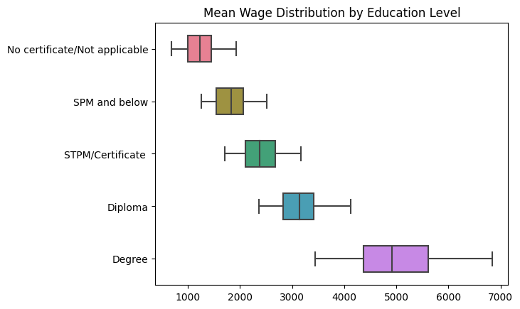

```python
# Plot the distribution of mean wage by education
g2 = sns.boxplot(data=cert2_df, x="mean", y="variable_en", width=0.5, palette='husl')
g2.set(xlabel="", ylabel="")

plt.title("Mean Wage Distribution by Education Level")
plt.show()
```

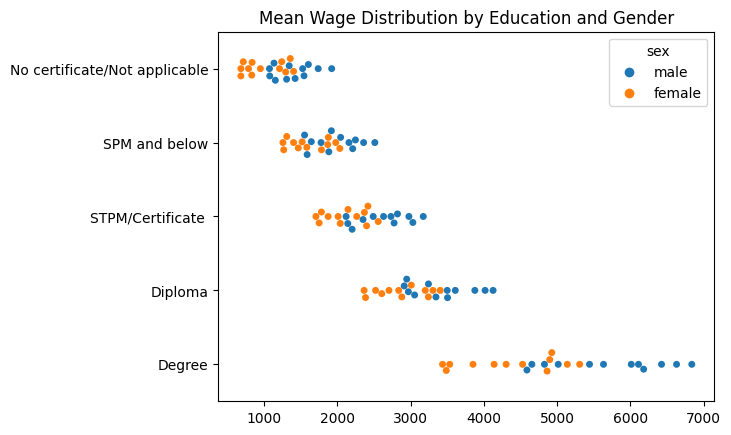

```python
# Remove 'Overall' in the 'Sex' column
cert2_df = cert2_df[cert2_df['sex'] != 'overall']

# Plot the distribution of mean wage by education and gender
g3 = sns.swarmplot(data=cert2_df, x="mean", y="variable_en", hue="sex")
g3.set(xlabel="", ylabel="")

plt.title("Mean Wage Distribution by Education and Gender")
plt.show()
```

```python
#Next, we explore ethnicity dataset
ethnics_df.head()
```

|  | variable | variable_en | variable_bm | sex | year | mean | median | recipients |
| --- | --- | --- | --- | --- | --- | --- | --- | --- |
| 0 | overall | Overall | Keseluruhan | overall | 2010 | 1792.0 | 1300.0 | 8414600 |
| 1 | overall | Overall | Keseluruhan | overall | 2011 | 1809.0 | 1320.0 | 8983400 |
| 2 | overall | Overall | Keseluruhan | overall | 2012 | 1906.0 | 1450.0 | 9166200 |
| 3 | overall | Overall | Keseluruhan | overall | 2013 | 2023.0 | 1500.0 | 9540600 |
| 4 | overall | Overall | Keseluruhan | overall | 2014 | 2193.0 | 1500.0 | 10146600 |

```python
print('Race',ethnics_df.variable_en.unique())
```

```
Race ['Overall' 'Citizen' 'Bumiputera' 'Chinese' 'Indian ' 'Other (Citizen)'
 'Non-Citizen']
```

```python
# Remove Overall and Sort by Mean
ethnics2_df = ethnics_df[ethnics_df['variable_en'] != 'Overall']
ethnics2_df[['variable_en', 'mean']].groupby(['variable_en'], as_index=False).mean().sort_values(by='mean', ascending=False)
```

|  | variable_en | mean |
| --- | --- | --- |
| 1 | Chinese | 2888.189749 |
| 2 | Citizen | 2555.729951 |
| 0 | Bumiputera | 2460.856442 |
| 3 | Indian | 2387.707240 |
| 5 | Other (Citizen) | 1807.029689 |
| 4 | Non-Citizen | 1330.942241 |

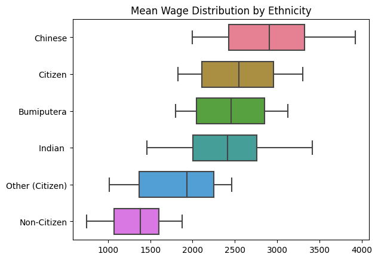

```python
# Plot the distribution of mean wage by ethnicity
g4 = sns.boxplot(data=ethnics2_df, x="mean", y="variable_en",
                 order=['Chinese', 'Citizen', 'Bumiputera', 'Indian ', 'Other (Citizen)', 'Non-Citizen'],
                 width=0.7, palette='husl')
g4.set(xlabel="", ylabel="")

plt.title("Mean Wage Distribution by Ethnicity")
plt.show()
```

```python
#Finally, we look into industry dataset
industry_df.head()
```

|  | variable | variable_en | variable_bm | sex | year | mean | median | recipients |
| --- | --- | --- | --- | --- | --- | --- | --- | --- |
| 0 | overall | Overall | Keseluruhan | overall | 2010 | 1936.0 | 1500.0 | 7149200 |
| 1 | overall | Overall | Keseluruhan | overall | 2011 | 1959.0 | 1500.0 | 7634000 |
| 2 | overall | Overall | Keseluruhan | overall | 2012 | 2052.0 | 1566.0 | 7782900 |
| 3 | overall | Overall | Keseluruhan | overall | 2013 | 2186.0 | 1700.0 | 7903100 |
| 4 | overall | Overall | Keseluruhan | overall | 2014 | 2377.0 | 1800.0 | 8392400 |

```python
print('Industry',industry_df.variable_en.unique())
```

```
Industry ['Overall' 'Agriculture' 'Mining and quarrying ' 'Manufacturing'
 'Electricity, gas, steam and air conditioning supply '
 'Water supply; sewerage, waste management and remediation activities '
 'Construction '
 'Wholesale and retail trade; repair of motor vehicles and motorcycles '
 'Transportation and storage'
 'Accommodation and food and beverage service activities'
 'Information and communication'
 'Financial and insurance/takaful activities ' 'Real estate activities '
 'Professional, scientific and technical activities'
 'Administrative and support service activities '
 'Public administration and defence; compulsory social security'
 'Education ' 'Human health and social work activities '
 'Arts, entertainment and recreation' 'Other service activities']
```

```python
# Remove Overall and Sort by Mean
industry2_df = industry_df[industry_df['variable_en'] != 'Overall']
industry2_df[['variable_en', 'mean']].groupby(['variable_en'], as_index=False).mean().sort_values(by='mean', ascending=False)
```

|  | variable_en | mean |
| --- | --- | --- |
| 11 | Mining and quarrying | 4628.683333 |
| 5 | Education | 4176.644444 |
| 15 | Real estate activities | 3930.411111 |
| 9 | Information and communication | 3854.263889 |
| 7 | Financial and insurance/takaful activities | 3822.325000 |
| 13 | Professional, scientific and technical activities | 3555.769444 |
| 6 | Electricity, gas, steam and air conditioning s... | 3425.075000 |
| 8 | Human health and social work activities | 3378.111111 |
| 14 | Public administration and defence; compulsory ... | 3329.558333 |
| 16 | Transportation and storage | 2365.522222 |
| 4 | Construction | 2282.605556 |
| 10 | Manufacturing | 2169.775000 |
| 17 | Water supply; sewerage, waste management and r... | 2161.508333 |
| 3 | Arts, entertainment and recreation | 2124.527778 |
| 12 | Other service activities | 1821.388889 |
| 18 | Wholesale and retail trade; repair of motor ve... | 1817.541667 |
| 1 | Administrative and support service activities | 1648.647222 |
| 0 | Accommodation and food and beverage service ac... | 1553.355556 |
| 2 | Agriculture | 1480.583333 |

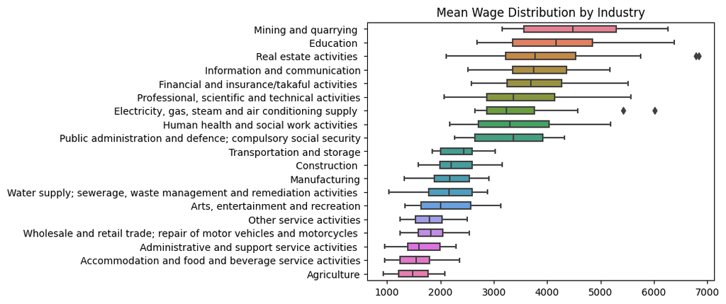

```python
# Plot the distribution of mean wage by industry
g5 = sns.boxplot(data=industry2_df, x="mean", y="variable_en",
                 order=['Mining and quarrying ', 'Education ', 'Real estate activities ', 'Information and communication', 'Financial and insurance/takaful activities ',
                        'Professional, scientific and technical activities', 'Electricity, gas, steam and air conditioning supply ', 'Human health and social work activities ',
                        'Public administration and defence; compulsory social security', 'Transportation and storage', 'Construction ', 'Manufacturing',
                        'Water supply; sewerage, waste management and remediation activities ', 'Arts, entertainment and recreation', 'Other service activities',
                        'Wholesale and retail trade; repair of motor vehicles and motorcycles ', 'Administrative and support service activities ',
                        'Accommodation and food and beverage service activities', 'Agriculture'],
                 width=0.5, palette='husl')
g5.set(xlabel="", ylabel="")

plt.title("Mean Wage Distribution by Industry")
plt.show()
```